# hierarchical clustering

with increment in within SS (Ward)

The Ward.D (and, Ward.D2) aggregation methods that can be selected in the standard **hclust** function are based on the Lance-Williams formula (that generalizes at any linkage function). To keep it simple, and to avoid computing the full hierarchy for each permutation, we use the **Minimum Increase of Sum of Squares (MISSQ)** computed at each split

$$MISSQ:\frac{|L| \cdot |R|}{|L\cup R|}\|\mu_{L}-\mu_{R}\|{2} = \sum_{x_{i}\in (L\cup R)}\|x_{i}-\mu_{(L\cup R)} \|^{2} - \sum_{x_{i}\in (L)}\|x_{i}-\mu_{(L)} \|^{2} - \sum_{x_{i}\in (R)}\|x_{i}-\mu_{(R)} \|^{2} \ \ \ (1)$$
that is, the increase in the $SS$ due to the merge.

The quantities in Equation (1) can also be computed via pairwise distances, since, for the general group A, the following equation holds

$$\sum_{x_{i}\in A}\|x_{i}-\mu_{A} \|^{2} = \frac{1}{|A|}\sum_{i=1}^{|A|-1}\sum_{j=2}^{|A|}\|x_{i}-x_{j} \|^{2} \ \ \ (2)$$
where $|A|$ indicates the group size.

- To build the hierarchy, the right-hand side of Equation (2) is used.
- When it comes to re-compute the increase of SS of the split for the permutation test, the left-hand side of Equation (1) is usefull (very quick to compute).

### Setup

```r
library(AmesHousing)
library(tidyverse)
library(tidymodels)
source("R/linkage_maker.R")
source("R/my_hclust.R")
source("R/single_div_step.R")
```

Two functions are created

- **my_hclust** : performs agglomerative clustering with custom linkage
- **linkage_maker** : implements the Ward linkage, and it can be easily generalised to any linkage

### Toy experiment

Generate data and compute the pairwise Euclidean distances

```r
set.seed(123)
toy_data=tibble(x1=round(runif(1:10,min=2,max=15)),
                x2=round(runif(1:10,min=1,max=4))
                )

toy_dist=dist(toy_data)
```

Perform standard **hclust** on the toy data

```r
toy_hc= hclust(toy_dist^2,method="ward.D2")
```

Check that the aggregation sequence is the same

**aggregation sequence via custom hclust**

```r
my_hclust(toy_dist^2)
```

```
# A tibble: 8 × 2
  merged            linkage
  <chr>               <dbl>
1 05_08                0
2 07_09                0
3 01_03                1
4 02_04                1
5 01_03_10             1.67
6 02_04_05_08          4.5
7 01_03_10_07_09       8.13
8 01_03_10_07_09_06   20.0
```

**dendrogram representation (via hclust)**

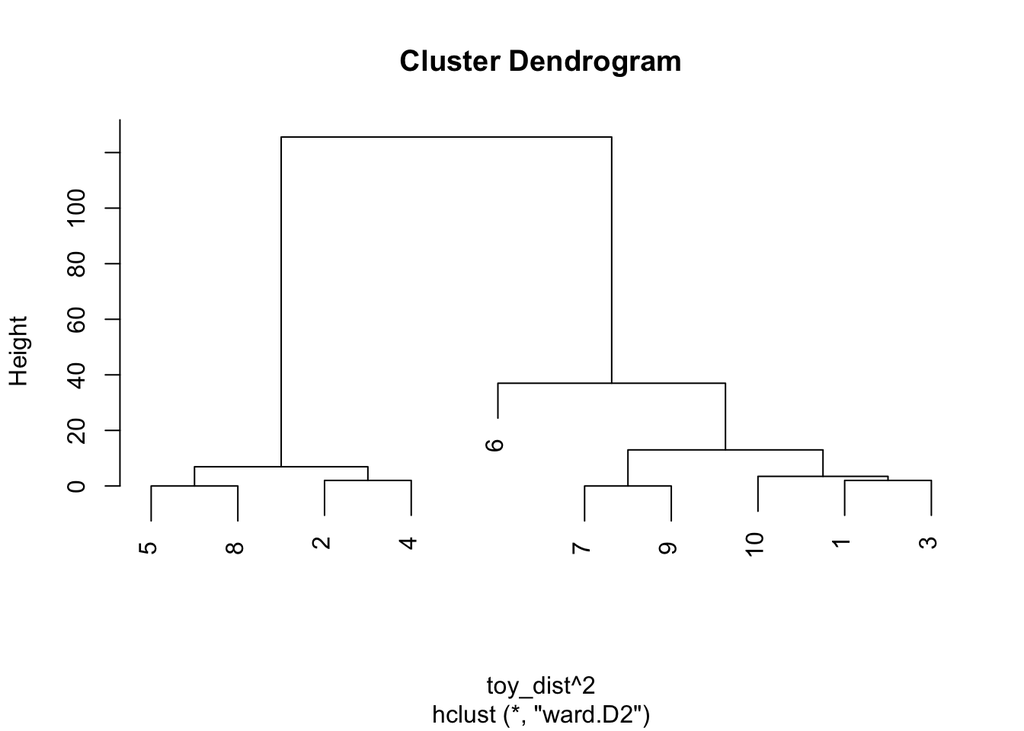

## Single knot divisive step

We need a function that takes as input

- the distance matrix

returns

- cluster: L/R membership
- the sphere of the full set (equiv to $h(L\cup R)$ in case of complete linkage)
- the spheres of the $L$ and $R$ sets (equiv to $h(L)$ and $h(R)$ in case of complete linkage)

the core of the procedure is

- step 1 identify the point with the largest average distance from all of the others; make that point be the first in the **splinter** set, and remove it from the original set
- step 2 re-compute the average distances of the points left in the original set, and the average distance of the original points to the points in the splinter set
- step 3 compute the difference between the distances in step 2, and identify the max difference.
  - if the max difference is negative, break
  - otherwise, assign the correponding point to the splinter set and go back to step 2

The procedure is implemented in the function **single_div_step** that takes as input a **matrix** of distances with row/col names explicitly specified (no *dist* object)

As an example, this is the tiny matrix used on the Rousseeuw book.

```r
source("R/single_div_step.R")
rus_mat = matrix(c(0,2,6,10,9,2,0,5,9,8,6,5,0,4,5,10,9,4,0,3,9,8,5,3,0),nrow=5, byrow = TRUE)
row.names(rus_mat)=letters[1:nrow(rus_mat)]
colnames(rus_mat)=letters[1:nrow(rus_mat)]

out_rus = single_div_step(rus_mat)
out_rus
```

```
$cluster
[1] "R" "R" "L" "L" "L"

$d_L_u_R
[1] 10

$d_L
[1] 5

$d_R
[1] 2
```

**single split result**

```r
toy_dist_mat=as.matrix(toy_dist)
row.names(toy_dist_mat)=letters[1:nrow(toy_dist_mat)]
colnames(toy_dist_mat)=letters[1:nrow(toy_dist_mat)]
toy_out = single_div_step(toy_dist_mat)
toy_out
```

```
$cluster
 [1] "R" "L" "R" "L" "L" "R" "R" "L" "R" "R"

$d_L_u_R
[1] 11.40175

$d_L
[1] 2.236068

$d_R
[1] 6.324555
```

**dendrogram representation (via hclust)**

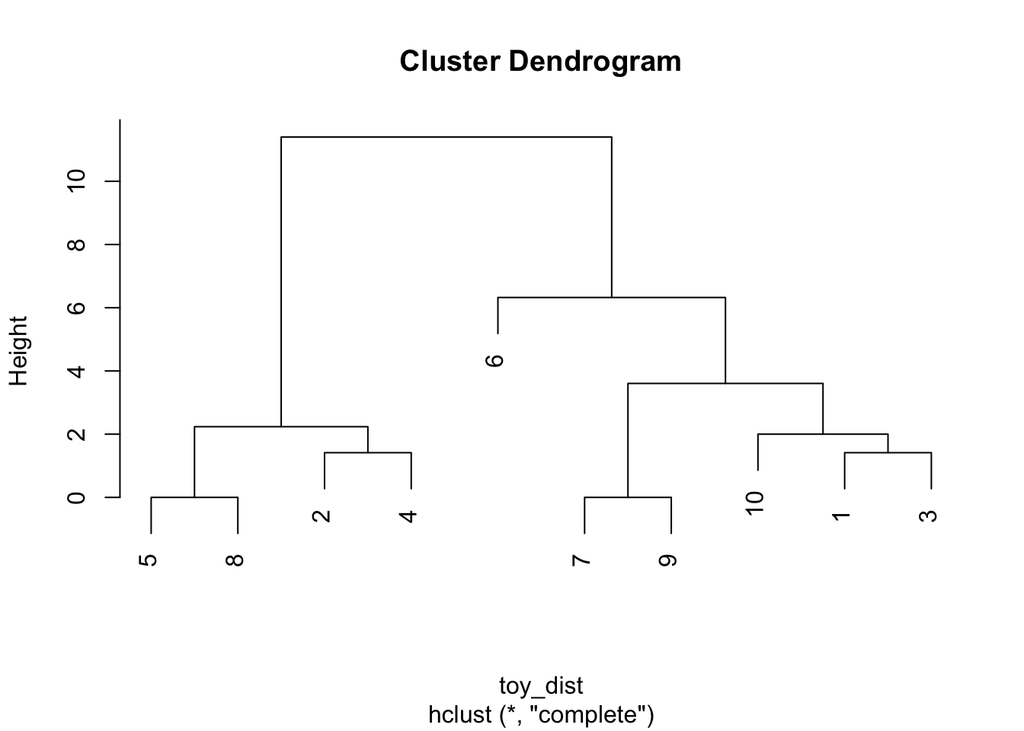

```r
table(cutree(toy_hc,k = 2),toy_out$cluster)
```

```
    L R
  1 0 6
  2 4 0
```

### A more serious example

```r
ames_ready = ames_raw |> recipe(formula = ~.) |>
  step_select(all_numeric()) |>
  step_normalize(all_predictors()) |>
  step_impute_knn(all_numeric(),skip = T) |>
  prep(fresh=T,training=ames_raw) |> bake(new_data=NULL)

ames_dist=ames_ready |> dist()

ames_dist_mat=as.matrix(ames_dist)
# ames_dist_mat[1:5,1:5]
row.names(ames_dist_mat)=1:nrow(ames_dist_mat)
colnames(ames_dist_mat)=1:nrow(ames_dist_mat)

microbenchmark::microbenchmark(
out_den=hclust(ames_dist,method="complete"),
out_div=single_div_step(ames_dist_mat),
out_km=kmeans(ames_ready,centers = 2)
)
```

```
Unit: milliseconds
    expr        min         lq       mean     median        uq        max neval
 out_den  62.478834  63.616215  67.850374  66.066600  69.17083  91.770423   100
 out_div 198.879684 202.893277 215.808702 204.420793 207.16392 374.866444   100
  out_km   1.955823   2.983447   3.115208   3.112351   3.20864   5.618722   100
```